# Exploring the Relationship Between Median Income and Institutional Trust

James Walsh and Richard Sedlmayr

## 0.1 Introduction

This memo investigates the empirical relationship between median household income and public trust in institutions in the United States. The objective is not to establish causality but to assess whether a statistically coherent relationship exists, and how that relationship behaves under different specifications.

## 0.2 Conceptual Framework

Economic conditions are often assumed to influence institutional trust. The underlying logic is that economic growth may signal competent governance, while stagnation may undermine confidence in institutions. However, trust may also respond to broader societal factors, including polarization, media narratives, or exogenous shocks.

This analysis remains agnostic about causal direction and aims instead to descriptively trace whether income and trust have moved together — and under what temporal dynamics.

## 0.3 Data Sources

Two national-level time series are used:

- **Trust in institutions**: Survey-based data compiled from Pew, CNN, and CBS/NYT from 1960s–2020s, measured as the percentage of respondents reporting that they trust the federal government to do what is right.

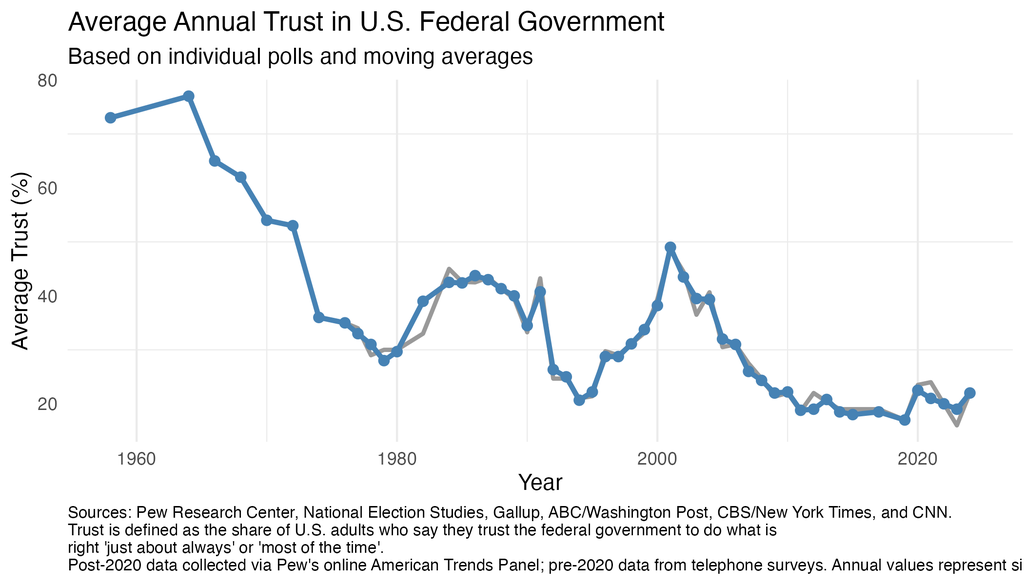

- **Income**: Real median disposable household income (equivalized and post-tax), sourced from the Luxembourg Income Study, expressed in international dollars at 2017 prices.

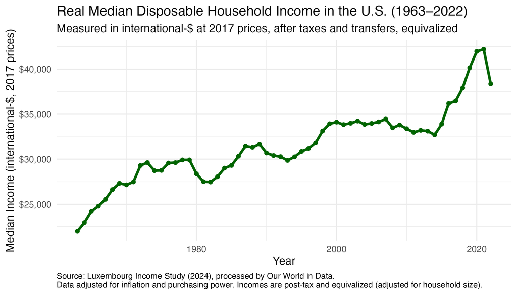

Both series are harmonized at the yearly level.

## 0.4 Modeling Strategy

We explore two classes of models:

- **Level-on-level**:
  $$\text{Trust}_t = \beta_0 + \beta_1 \cdot \text{Income}_t + \varepsilon_t$$
- **Change-on-change**:
  $$\Delta \text{Trust}_t = \gamma_0 + \gamma_1 \cdot \Delta \text{Income}_t
  + \eta_t$$

## 0.5 Level-on-Level Relationship

The figure above plots average trust in government against median household income (in 2017 international dollars), using both a linear trend (black line) and a non-parametric LOESS smoother (blue line).

While economic theory often predicts a positive association between income and institutional trust, this visualization reveals the opposite: trust appears to decline as income rises. The negative linear slope suggests that, on average, higher income levels correlate with lower trust in government.

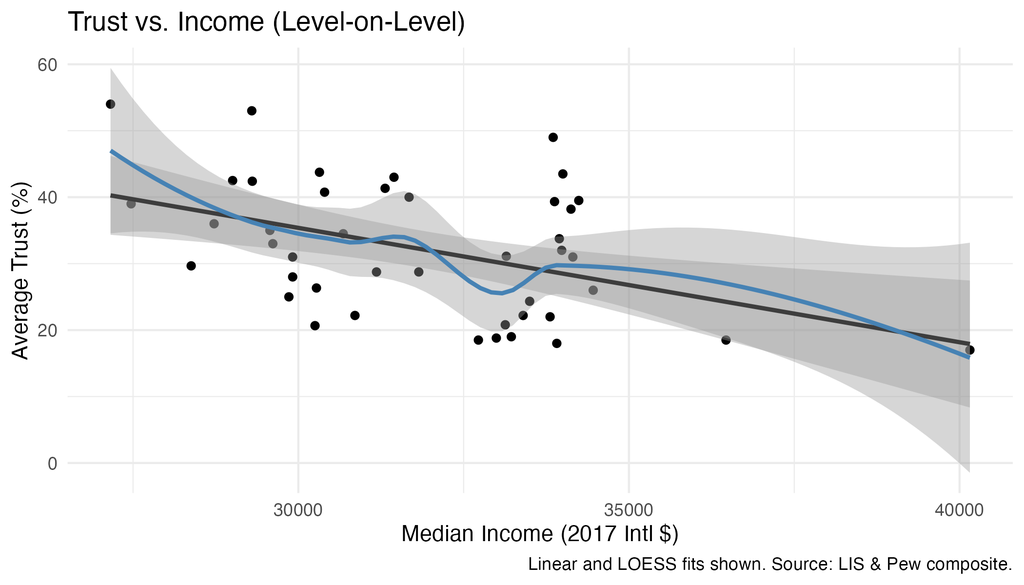

## 0.6 Change-on-Change Relationship

This figure examines the relationship between year-on-year changes in median income and changes in public trust in government. The black line depicts a linear regression fit, while the red LOESS curve allows for a more flexible, non-linear relationship.

The linear trend suggests a modestly positive association between income growth and changes in trust—when income rises, trust tends to increase slightly, though the slope is shallow and the confidence interval wide.

These dynamics imply that short-run economic gains may modestly boost institutional trust, but only within a narrow bandwidth. The high variability and weak slope underscore the importance of non-economic factors and the potential role of lags or cumulative effects over time.

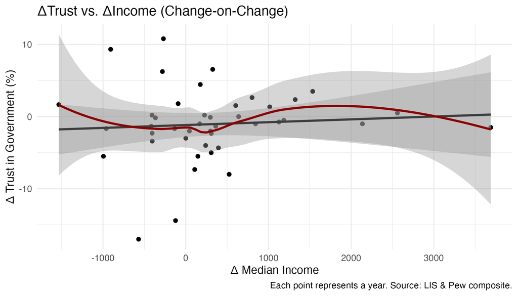

## 0.7 Regression Results (Selected)

This plot visualizes the estimated effects of income and its lags/leads on trust in government for both:

- Level-on-Level models (trust level ~ income level)
- Change-on-Change models (Δ trust ~ Δ income)

Our key findings are:

**Level-on-Level**:

- Most coefficients hover near zero and are statistically insignificant (95% CIs cross zero).
- The only marginally significant term is income_lag3, which is negative (suggesting a delayed erosion of trust following income gains or losses).
- Even median_income shows no consistent effect—highlighting the tenuous relationship in levels.

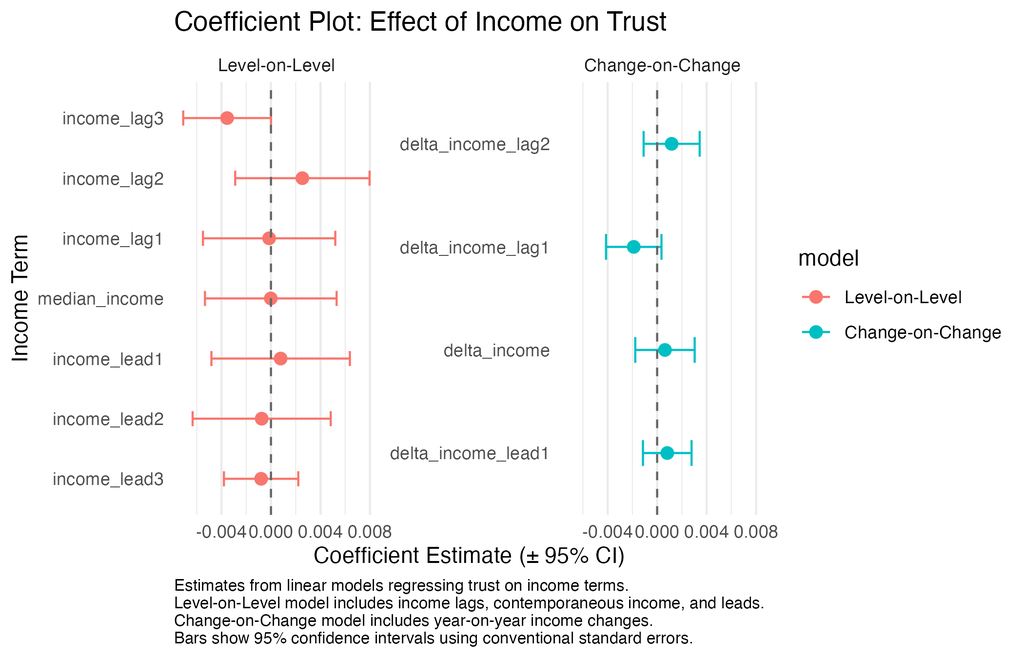

## 0.8 Interpretation and Next Steps

Taken together, the results indicate that median income is **not a strong standalone predictor** of institutional trust in the U.S. Over the past 60 years:

- **In level terms**, income and trust have moved in **opposite directions**, with trust declining even during periods of rising income.
- **In changes**, there is **some co-movement**, particularly for modest income gains, but the relationship is weak and noisy.
- **Regression analysis** reinforces the descriptive patterns: coefficients are generally small, imprecise, and unstable across lags and leads.

These findings suggest that trust dynamics may be driven more by political, cultural, or institutional shocks than by macroeconomic fundamentals alone.

### 0.8.1 Next Steps

To better understand the drivers of trust, we propose:

- **Adding controls**: Incorporate variables such as unemployment, inflation, media trust, or political polarization.
- **Cross-validation**: Compare U.S. trends with other high-income democracies using LIS and OECD harmonized trust data.
- **Decomposition**: Examine subgroup trends (e.g., by income quintile or partisan ID) to identify heterogeneous patterns masked in the aggregate.

# 1 Appendix

## 1.1 Newey-West Adjusted Standard Errors

Newey-West adjusted standard errors help us get more reliable estimates when working with time series data—like trust and income over many years—by accounting for the fact that today’s outcomes are often influenced by yesterday’s. In ordinary regression models, we assume that each data point is independent. But with time series, that’s rarely true: shocks or patterns often carry over from one year to the next. If we ignore this, our calculations of uncertainty can be misleading—making effects look more precise (or significant) than they really are.

After applying Newey-West corrections, the results show that median income remains a weak and inconsistent predictor of institutional trust. In the level-on-level model, none of the income terms—past, present, or future—are statistically significant, even with robust standard errors. In the change-on-change model, only one lagged term (lag(delta_income, 1)) reaches marginal significance (p = 0.043), suggesting that trust might decline slightly following income increases—but this effect is small, and no other terms are statistically meaningful.

The takeaway is that any associations between income and trust are statistically fragile and do not hold up under more rigorous inference.

```
##
## t test of coefficients:
##
##                  Estimate  Std. Error t value Pr(>|t|)
## (Intercept)    9.3002e+01  1.1858e+02  0.7843   0.4381
## income_lag3   -3.5444e-03  3.5370e-03 -1.0021   0.3232
## income_lag2    2.5398e-03  5.1157e-03  0.4965   0.6227
## income_lag1   -1.4803e-04  3.8824e-03 -0.0381   0.9698
## median_income -1.3979e-05  2.4568e-03 -0.0057   0.9955
## income_lead1   7.8298e-04  4.2980e-03  0.1822   0.8565
## income_lead2  -7.4924e-04  3.7854e-03 -0.1979   0.8442
## income_lead3  -7.9581e-04  7.5842e-04 -1.0493   0.3012
```

```
##
## t test of coefficients:
##
##                       Estimate  Std. Error t value Pr(>|t|)
## (Intercept)        -1.06967905  0.83163291 -1.2862  0.20680
## delta_income_lag2   0.00117245  0.00122984  0.9533  0.34696
## delta_income_lag1  -0.00188928  0.00089765 -2.1047  0.04257 *
## delta_income        0.00063337  0.00067418  0.9395  0.35393
## delta_income_lead1  0.00081857  0.00064343  1.2722  0.21169
## ---
## Signif. codes:  0 '***' 0.001 '**' 0.01 '*' 0.05 '.' 0.1 ' ' 1
```

## 1.2 Residual Autocorrelation Diagnostics

### 1.2.1 Durbin-Watson Tests

The Durbin-Watson test helps detect whether a regression model’s errors are autocorrelated—that is, whether the “leftover noise” from one year is similar to the noise in the next. This matters because if errors are correlated over time, our estimates of uncertainty (standard errors) may be misleading—potentially making us overconfident in results that are actually fragile.

For the level-on-level model, the Durbin-Watson statistic is 0.51 with a p-value effectively zero. Since a value of 2 indicates no autocorrelation, and values below 2 indicate positive autocorrelation, this result strongly suggests that the model’s residuals are highly autocorrelated. In other words, the model is missing key time-dependent structure or dynamics in the data.

For the change-on-change model, the Durbin-Watson statistic is 1.71, with a p-value of 0.16. This value is closer to 2 and not statistically significant, meaning there’s no strong evidence of autocorrelation in the residuals of this differenced model. This is consistent with expectations—first-differencing often helps eliminate trends and persistent patterns.

```
##
##  Durbin-Watson test
##
## data:  model_lags
## DW = 0.51424, p-value = 1.453e-09
## alternative hypothesis: true autocorrelation is greater than 0
```

```
##
##  Durbin-Watson test
##
## data:  model_change_lags
## DW = 1.7072, p-value = 0.1566
## alternative hypothesis: true autocorrelation is greater than 0
```

### 1.2.2 Breusch-Godfrey Tests (lags = 3)

Breusch-Godfrey Tests check whether the “errors” left over from our models—what the regression couldn’t explain—are following a predictable pattern across time. If they are, it means the model is missing something important about how trust and income evolve from year to year. This issue is called serial correlation or autocorrelation, and if it’s present, we can’t fully trust our estimates of uncertainty.

In the level-on-level model (where we compare the level of income to the level of trust), the test detects strong evidence of autocorrelation: the p-value is near zero. This tells us that the unexplained variation in trust isn’t random—it’s systematically linked to past years. This reinforces the need for more sophisticated modeling or adjustments (like the Newey-West corrections we’ve used).

In contrast, the change-on-change model (which looks at how income and trust move year-to-year) shows no such pattern. The test result here is clearly not significant (p = 0.74), meaning the leftover variation looks random—just what we want. This suggests the change model is better behaved statistically, and may be a more reliable way to study how trust and income relate over time.

```
##
##  Breusch-Godfrey test for serial correlation of order up to 3
##
## data:  model_lags
## LM test = 25.115, df = 3, p-value = 1.461e-05
```

```
##
##  Breusch-Godfrey test for serial correlation of order up to 3
##
## data:  model_change_lags
## LM test = 1.2488, df = 3, p-value = 0.7413
```

### 1.2.3 ACF Plots of Residuals

These plots show whether the “unexplained part” of the model—the residuals—follows a systematic pattern over time. Each vertical bar represents how strongly the model’s errors are correlated with themselves at different lags (1 year apart, 2 years apart, etc.). If the bars fall outside the blue dotted lines, that correlation is likely not due to random chance.

In the level-on-level model, the pattern is clear: the residuals are strongly autocorrelated. The first few bars are very high and only slowly decline, meaning that whatever the model fails to capture in one year tends to carry over into the next—and the next after that. This suggests the model may be missing important time-based structure, like broader trends or cycles. In short, the errors are not random; they’re systematic.

By contrast, in the change-on-change model, the residuals look much closer to random noise. Most bars are short and stay within the blue lines, meaning the unexplained variation doesn’t show a strong pattern over time. This supports the idea that differencing the data (i.e. focusing on year-to-year changes) helps clean up the time-related noise, and that this version of the model may be statistically better behaved.

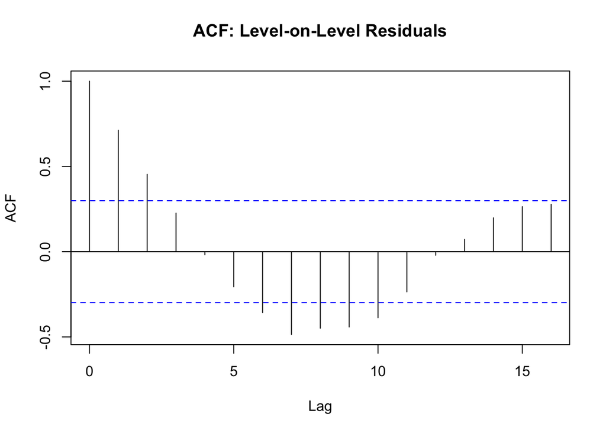

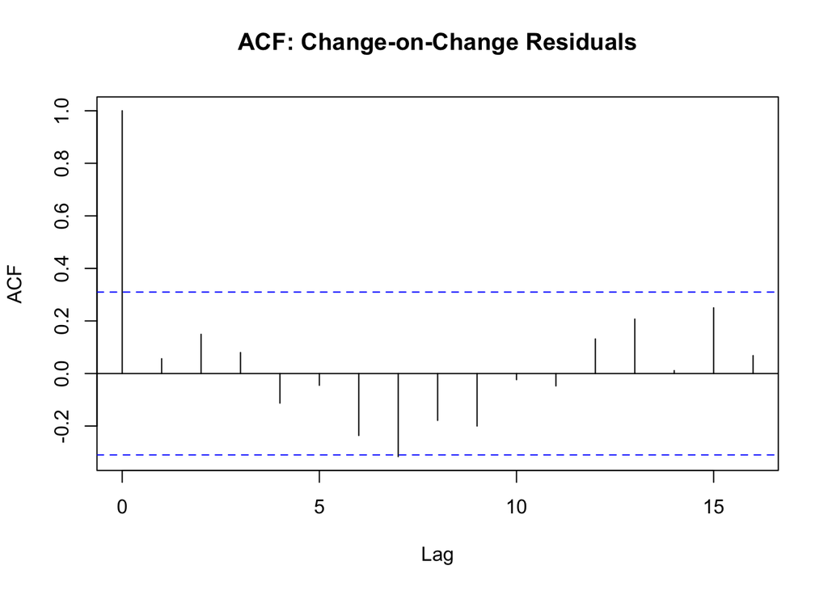

## 1.3 Interpretation

- The Durbin-Watson and Breusch-Godfrey tests check for autocorrelation in the residuals.
- Newey-West standard errors adjust for this autocorrelation when estimating the uncertainty of regression coefficients.
- Interpretation should focus on whether statistical significance changes meaningfully when using robust SEs.